# задание 1

**подключение библиотек, загрузка файла, вывод первых 10 строк**

```python
import pandas as pd
import numpy as np
import matplotlib.pyplot as plt

df = pd.read_csv("C:/Users/bobrz/Desktop/vgsales.csv")

df.head(10)
```

|  | Rank | Name | Platform | Year | Genre | Publisher | NA_Sales | EU_Sales | JP_Sales | Other_Sales | Global_Sales |
| --- | --- | --- | --- | --- | --- | --- | --- | --- | --- | --- | --- |
| 0 | 1 | Wii Sports | Wii | 2006.0 | Sports | Nintendo | 41.49 | 29.02 | 3.77 | 8.46 | 82.74 |
| 1 | 2 | Super Mario Bros. | NES | 1985.0 | Platform | Nintendo | 29.08 | 3.58 | 6.81 | 0.77 | 40.24 |
| 2 | 3 | Mario Kart Wii | Wii | 2008.0 | Racing | Nintendo | 15.85 | 12.88 | 3.79 | 3.31 | 35.82 |
| 3 | 4 | Wii Sports Resort | Wii | 2009.0 | Sports | Nintendo | 15.75 | 11.01 | 3.28 | 2.96 | 33.00 |
| 4 | 5 | Pokemon Red/Pokemon Blue | GB | 1996.0 | Role-Playing | Nintendo | 11.27 | 8.89 | 10.22 | 1.00 | 31.37 |
| 5 | 6 | Tetris | GB | 1989.0 | Puzzle | Nintendo | 23.20 | 2.26 | 4.22 | 0.58 | 30.26 |
| 6 | 7 | New Super Mario Bros. | DS | 2006.0 | Platform | Nintendo | 11.38 | 9.23 | 6.50 | 2.90 | 30.01 |
| 7 | 8 | Wii Play | Wii | 2006.0 | Misc | Nintendo | 14.03 | 9.20 | 2.93 | 2.85 | 29.02 |
| 8 | 9 | New Super Mario Bros. Wii | Wii | 2009.0 | Platform | Nintendo | 14.59 | 7.06 | 4.70 | 2.26 | 28.62 |
| 9 | 10 | Duck Hunt | NES | 1984.0 | Shooter | Nintendo | 26.93 | 0.63 | 0.28 | 0.47 | 28.31 |

# задание 2

```python
print("Количество строк:", df.shape[0])
print("Количество столбцов:", df.shape[1])
print("\nНазвания столбцов:")
print(df.columns.tolist())
print("\nТипы данных:")
print(df.dtypes)
print("\nСтатистические характеристики:")
print(df.describe())
```

```
Количество строк: 16598
Количество столбцов: 11

Названия столбцов:
['Rank', 'Name', 'Platform', 'Year', 'Genre', 'Publisher', 'NA_Sales', 'EU_Sales', 'JP_Sales', 'Other_Sales', 'Global_Sales']

Типы данных:
Rank              int64
Name             object
Platform         object
Year            float64
Genre            object
Publisher        object
NA_Sales        float64
EU_Sales        float64
JP_Sales        float64
Other_Sales     float64
Global_Sales    float64
dtype: object

Статистические характеристики:
               Rank          Year      NA_Sales      EU_Sales      JP_Sales  \
count  16598.000000  16327.000000  16598.000000  16598.000000  16598.000000
mean    8300.605254   2006.406443      0.264667      0.146652      0.077782
std     4791.853933      5.828981      0.816683      0.505351      0.309291
min        1.000000   1980.000000      0.000000      0.000000      0.000000
25%     4151.250000   2003.000000      0.000000      0.000000      0.000000
50%     8300.500000   2007.000000      0.080000      0.020000      0.000000
75%    12449.750000   2010.000000      0.240000      0.110000      0.040000
max    16600.000000   2020.000000     41.490000     29.020000     10.220000

        Other_Sales  Global_Sales
count  16598.000000  16598.000000
mean       0.048063      0.537441
std        0.188588      1.555028
min        0.000000      0.010000
25%        0.000000      0.060000
50%        0.010000      0.170000
75%        0.040000      0.470000
max       10.570000     82.740000
```

**какие столбцы являются числовыми**

```python
numeric_cols = df.select_dtypes(include=["int64", "float64"]).columns.tolist()
numeric_cols
```

```
['Rank',
 'Year',
 'NA_Sales',
 'EU_Sales',
 'JP_Sales',
 'Other_Sales',
 'Global_Sales']
```

**какие столбцы являются текстовыми**

```python
text_cols = df.select_dtypes(include=["object"]).columns.tolist()
text_cols
```

```
['Name', 'Platform', 'Genre', 'Publisher']
```

**какие столбцы содержат данные о продажах**

```python
sales_cols = [col for col in df.columns if "Sales" in col]
sales_cols
```

```
['NA_Sales', 'EU_Sales', 'JP_Sales', 'Other_Sales', 'Global_Sales']
```

# задание 3

**в каких столбцах имеются пропуски**

```python
df.isnull().sum()
```

```
Rank              0
Name              0
Platform          0
Year            271
Genre             0
Publisher        58
NA_Sales          0
EU_Sales          0
JP_Sales          0
Other_Sales       0
Global_Sales      0
dtype: int64
```

```python
cols_with_na = df.columns[df.isnull().any()].tolist()
cols_with_na
```

```
['Year', 'Publisher']
```

**сколько пропущенных значений находится в каждом таком столбце**

```python
df.isnull().sum()[df.isnull().sum() > 0]
```

```
Year         271
Publisher     58
dtype: int64
```

**какой столбец содержит больше всего пропусков**

```python
df.isnull().sum().idxmax(), df.isnull().sum().max()
```

```
('Year', 271)
```

**строки, в которых отсутствует значение Year**

```python
df[df["Year"].isnull()]
```

|  | Rank | Name | Platform | Year | Genre | Publisher | NA_Sales | EU_Sales | JP_Sales | Other_Sales | Global_Sales |
| --- | --- | --- | --- | --- | --- | --- | --- | --- | --- | --- | --- |
| 179 | 180 | Madden NFL 2004 | PS2 | NaN | Sports | Electronic Arts | 4.26 | 0.26 | 0.01 | 0.71 | 5.23 |
| 377 | 378 | FIFA Soccer 2004 | PS2 | NaN | Sports | Electronic Arts | 0.59 | 2.36 | 0.04 | 0.51 | 3.49 |
| 431 | 432 | LEGO Batman: The Videogame | Wii | NaN | Action | Warner Bros. Interactive Entertainment | 1.86 | 1.02 | 0.00 | 0.29 | 3.17 |
| 470 | 471 | wwe Smackdown vs. Raw 2006 | PS2 | NaN | Fighting | NaN | 1.57 | 1.02 | 0.00 | 0.41 | 3.00 |
| 607 | 608 | Space Invaders | 2600 | NaN | Shooter | Atari | 2.36 | 0.14 | 0.00 | 0.03 | 2.53 |
| ... | ... | ... | ... | ... | ... | ... | ... | ... | ... | ... | ... |
| 16307 | 16310 | Freaky Flyers | GC | NaN | Racing | Unknown | 0.01 | 0.00 | 0.00 | 0.00 | 0.01 |
| 16327 | 16330 | Inversion | PC | NaN | Shooter | Namco Bandai Games | 0.01 | 0.00 | 0.00 | 0.00 | 0.01 |
| 16366 | 16369 | Hakuouki: Shinsengumi Kitan | PS3 | NaN | Adventure | Unknown | 0.01 | 0.00 | 0.00 | 0.00 | 0.01 |
| 16427 | 16430 | Virtua Quest | GC | NaN | Role-Playing | Unknown | 0.01 | 0.00 | 0.00 | 0.00 | 0.01 |
| 16493 | 16496 | The Smurfs | 3DS | NaN | Action | Unknown | 0.00 | 0.01 | 0.00 | 0.00 | 0.01 |

271 rows × 11 columns

# задание 4

**создание очищенного набора данных**

```python
df_clean = df.dropna(subset=["Year"])
```

**проверка размера исходный и очищенный**

```python
df.shape
df_clean.shape
```

```
(16327, 11)
```

**наличие пропусков**

```python
print(df_clean.isnull().sum())
```

```
Rank             0
Name             0
Platform         0
Year             0
Genre            0
Publisher       36
NA_Sales         0
EU_Sales         0
JP_Sales         0
Other_Sales      0
Global_Sales     0
dtype: int64
```

**кол-во строк было в исходном датасете**

```python
df.shape[0]
```

```
16598
```

**кол-во строк после удаления пропусков year в датасете**

```python
df_clean.shape[0]
```

```
16327
```

**почему, по вашему мнению, пропуски в Year могут мешать анализу игр по годам?**

пропуски в Year мешают анализу по годам из-за того что невозможно корректно сгруппировать данные и вознимают проблемы с типом данных

# задание 5

**изучение категориальных признаков**

```python
# Жанры
print("Жанры:", df_clean["Genre"].unique())
print("Количество жанров:", df_clean["Genre"].nunique())

# Платформы
print("\nПлатформы:", df_clean["Platform"].unique())
print("Количество платформ:", df_clean["Platform"].nunique())

# Издатели
print("\nКоличество издателей:", df_clean["Publisher"].nunique())
```

```
Жанры: ['Sports' 'Platform' 'Racing' 'Role-Playing' 'Puzzle' 'Misc' 'Shooter'
 'Simulation' 'Action' 'Fighting' 'Adventure' 'Strategy']
Количество жанров: 12

Платформы: ['Wii' 'NES' 'GB' 'DS' 'X360' 'PS3' 'PS2' 'SNES' 'GBA' '3DS' 'PS4' 'N64'
 'PS' 'XB' 'PC' '2600' 'PSP' 'XOne' 'GC' 'WiiU' 'GEN' 'DC' 'PSV' 'SAT'
 'SCD' 'WS' 'NG' 'TG16' '3DO' 'GG' 'PCFX']
Количество платформ: 31

Количество издателей: 576
```

**сколько жанров, платформ,издателей представлено**

```python
print("Жанров:", df_clean["Genre"].nunique())
print("Платформ:", df_clean["Platform"].nunique())
print("Издателей:", df_clean["Publisher"].nunique())
```

```
Жанров: 12
Платформ: 31
Издателей: 576
```

**какой из этих признаков имеет больше всего уникальных значений**

```python
df_clean[["Genre", "Platform", "Publisher"]].nunique()
```

```
Genre         12
Platform      31
Publisher    576
dtype: int64
```

# задание 6

**количество игр каждого жанра**

```python
genre_count = df_clean.groupby("Genre")["Name"].count()
```

**сортировка по убыванию**

```python
genre_count = genre_count.sort_values(ascending=False)
genre_count
```

```
Genre
Action          3253
Sports          2304
Misc            1710
Role-Playing    1471
Shooter         1282
Adventure       1276
Racing          1226
Platform         876
Simulation       851
Fighting         836
Strategy         671
Puzzle           571
Name: Name, dtype: int64
```

# задание 7

**суммарные мировые продажи по жанрам**

```python
genre_sales = df_clean.groupby("Genre")["Global_Sales"].sum()
genre_sales
```

```
Genre
Action          1722.88
Adventure        234.80
Fighting         444.05
Misc             797.62
Platform         829.15
Puzzle           242.22
Racing           726.77
Role-Playing     923.84
Shooter         1026.20
Simulation       390.16
Sports          1309.24
Strategy         173.43
Name: Global_Sales, dtype: float64
```

**сортировка по убыванию**

```python
genre_sales = genre_sales.sort_values(ascending=False)
genre_sales
```

```
Genre
Action          1722.88
Sports          1309.24
Shooter         1026.20
Role-Playing     923.84
Platform         829.15
Misc             797.62
Racing           726.77
Fighting         444.05
Simulation       390.16
Puzzle           242.22
Adventure        234.80
Strategy         173.43
Name: Global_Sales, dtype: float64
```

# задание 8

**сортировка по убыванию мировых продаж и беру 10 первых**

```python
top10_games = df_clean.sort_values("Global_Sales", ascending=False).head(10)
top10_games
```

|  | Rank | Name | Platform | Year | Genre | Publisher | NA_Sales | EU_Sales | JP_Sales | Other_Sales | Global_Sales |
| --- | --- | --- | --- | --- | --- | --- | --- | --- | --- | --- | --- |
| 0 | 1 | Wii Sports | Wii | 2006.0 | Sports | Nintendo | 41.49 | 29.02 | 3.77 | 8.46 | 82.74 |
| 1 | 2 | Super Mario Bros. | NES | 1985.0 | Platform | Nintendo | 29.08 | 3.58 | 6.81 | 0.77 | 40.24 |
| 2 | 3 | Mario Kart Wii | Wii | 2008.0 | Racing | Nintendo | 15.85 | 12.88 | 3.79 | 3.31 | 35.82 |
| 3 | 4 | Wii Sports Resort | Wii | 2009.0 | Sports | Nintendo | 15.75 | 11.01 | 3.28 | 2.96 | 33.00 |
| 4 | 5 | Pokemon Red/Pokemon Blue | GB | 1996.0 | Role-Playing | Nintendo | 11.27 | 8.89 | 10.22 | 1.00 | 31.37 |
| 5 | 6 | Tetris | GB | 1989.0 | Puzzle | Nintendo | 23.20 | 2.26 | 4.22 | 0.58 | 30.26 |
| 6 | 7 | New Super Mario Bros. | DS | 2006.0 | Platform | Nintendo | 11.38 | 9.23 | 6.50 | 2.90 | 30.01 |
| 7 | 8 | Wii Play | Wii | 2006.0 | Misc | Nintendo | 14.03 | 9.20 | 2.93 | 2.85 | 29.02 |
| 8 | 9 | New Super Mario Bros. Wii | Wii | 2009.0 | Platform | Nintendo | 14.59 | 7.06 | 4.70 | 2.26 | 28.62 |
| 9 | 10 | Duck Hunt | NES | 1984.0 | Shooter | Nintendo | 26.93 | 0.63 | 0.28 | 0.47 | 28.31 |

**вывожу только нужные столбцы**

```python
top10_games[["Rank", "Name", "Platform", "Genre", "Global_Sales"]]
```

|  | Rank | Name | Platform | Genre | Global_Sales |
| --- | --- | --- | --- | --- | --- |
| 0 | 1 | Wii Sports | Wii | Sports | 82.74 |
| 1 | 2 | Super Mario Bros. | NES | Platform | 40.24 |
| 2 | 3 | Mario Kart Wii | Wii | Racing | 35.82 |
| 3 | 4 | Wii Sports Resort | Wii | Sports | 33.00 |
| 4 | 5 | Pokemon Red/Pokemon Blue | GB | Role-Playing | 31.37 |
| 5 | 6 | Tetris | GB | Puzzle | 30.26 |
| 6 | 7 | New Super Mario Bros. | DS | Platform | 30.01 |
| 7 | 8 | Wii Play | Wii | Misc | 29.02 |
| 8 | 9 | New Super Mario Bros. Wii | Wii | Platform | 28.62 |
| 9 | 10 | Duck Hunt | NES | Shooter | 28.31 |

# задание 9

**количество игр по платформам**

```python
platform_count = df_clean.groupby("Platform")["Name"].count()
```

**сортировка по убыванию**

```python
platform_count = platform_count.sort_values(ascending=False)
platform_count
```

```
Platform
DS      2133
PS2     2127
PS3     1304
Wii     1290
X360    1235
PSP     1197
PS      1189
PC       943
GBA      811
XB       803
GC       542
3DS      500
PSV      412
PS4      336
N64      316
SNES     239
XOne     213
SAT      173
WiiU     143
2600     116
NES       98
GB        97
DC        52
GEN       27
NG        12
SCD        6
WS         6
3DO        3
TG16       2
PCFX       1
GG         1
Name: Name, dtype: int64
```

**10 платформ по количеству игр**

```python
top10_platforms_by_count = platform_count.head(10)
top10_platforms_by_count
```

```
Platform
DS      2133
PS2     2127
PS3     1304
Wii     1290
X360    1235
PSP     1197
PS      1189
PC       943
GBA      811
XB       803
Name: Name, dtype: int64
```

**суммарные продажи по платформам с сортировкой по убыванию**

```python
platform_sales = df_clean.groupby("Platform")["Global_Sales"].sum()
platform_sales = platform_sales.sort_values(ascending=False)
platform_sales
```

```
Platform
PS2     1233.46
X360     969.61
PS3      949.35
Wii      909.81
DS       818.96
PS       727.39
GBA      313.56
PSP      291.71
PS4      278.10
PC       255.05
GB       254.42
XB       252.09
NES      251.07
3DS      246.28
N64      218.21
SNES     200.05
GC       197.14
XOne     141.06
2600      86.57
WiiU      81.86
PSV       61.63
SAT       33.59
GEN       28.36
DC        15.97
SCD        1.87
NG         1.44
WS         1.42
TG16       0.16
3DO        0.10
GG         0.04
PCFX       0.03
Name: Global_Sales, dtype: float64
```

# задание 10

**сортировка продаж по жанрам (по убыванию)**

```python
genre_sales_sorted = genre_sales.sort_values(ascending=False)
```

**столбчатая диаграмма**

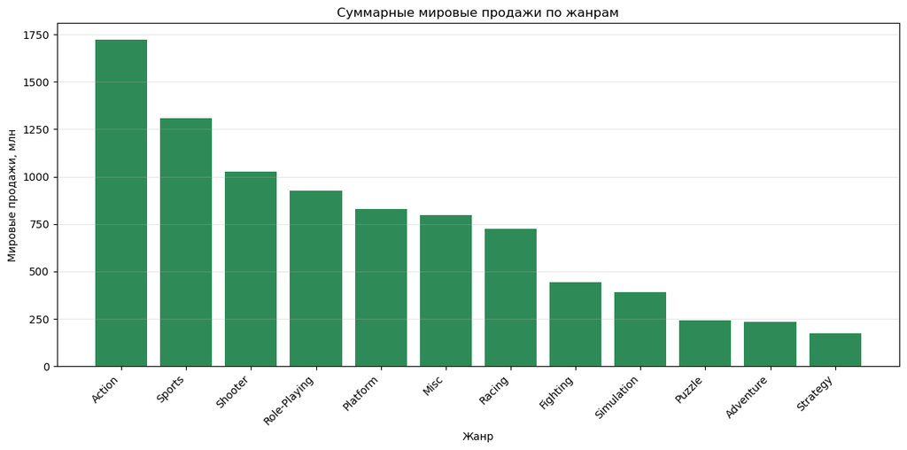

```python
plt.figure(figsize=(12, 6))
plt.bar(genre_sales_sorted.index, genre_sales_sorted.values, color="seagreen")
plt.xticks(rotation=45, ha="right")
plt.xlabel("Жанр")
plt.ylabel("Мировые продажи, млн")
plt.title("Суммарные мировые продажи по жанрам")
plt.grid(axis="y", alpha=0.3)
plt.tight_layout()
plt.show()
```

какие жанры имеют наибольшие продажи? Action, Sports, Shooter

какие жанры имеют наименьшие продажи? Puzzle, Strategy, Adventure

насколько сильно отличаются значения?

# задание 11

**коэффициент корреляции**

```python
corr_na_global = df_clean[["NA_Sales", "Global_Sales"]].corr()
corr_na_global
```

|  | NA_Sales | Global_Sales |
| --- | --- | --- |
| NA_Sales | 1.000000 | 0.941268 |
| Global_Sales | 0.941268 | 1.000000 |

получилось положительное или отрицательное значение? положительное

близко ли оно к 1? Да

можно ли говорить о выраженной положительной взаимосвязи между NA_Sales и Global_Sales?

Да, можно, из-за: Знак «+» — связь положительная. Значение 0.941 — очень близко к 1, что означает почти линейную зависимость. Логика данных.

# задание 12

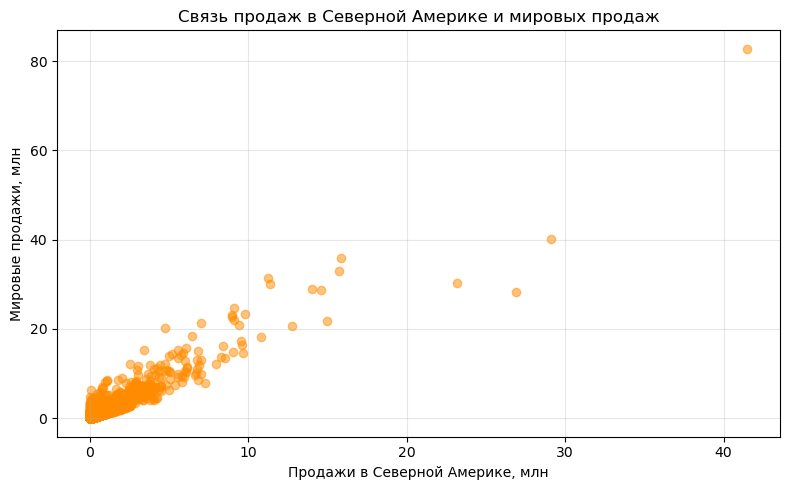

```python
import matplotlib.pyplot as plt

plt.figure(figsize=(8, 5))
plt.scatter(
    df_clean["NA_Sales"],
    df_clean["Global_Sales"],
    alpha=0.5,
    color="darkorange"
)
plt.xlabel("Продажи в Северной Америке, млн")
plt.ylabel("Мировые продажи, млн")
plt.title("Связь продаж в Северной Америке и мировых продаж")
plt.grid(True, alpha=0.3)
plt.tight_layout()
plt.show()
```

что обозначает одна точка на графике?

Одна точка = одна игра из датасета df_clean.

наблюдается ли восходящая тенденция?

Да, восходящая тенденция выражена отчётливо

соответствует ли график результату корреляционного анализа? Да

# задание 13

```python
region_corr = df_clean[
    ["NA_Sales", "EU_Sales", "JP_Sales", "Other_Sales"]
].corr()

region_corr
```

|  | NA_Sales | EU_Sales | JP_Sales | Other_Sales |
| --- | --- | --- | --- | --- |
| NA_Sales | 1.000000 | 0.768936 | 0.451285 | 0.634508 |
| EU_Sales | 0.768936 | 1.000000 | 0.436414 | 0.726266 |
| JP_Sales | 0.451285 | 0.436414 | 1.000000 | 0.290653 |
| Other_Sales | 0.634508 | 0.726266 | 0.290653 | 1.000000 |

Какие региональные продажи сильнее всего связаны между собой?